# 575 Final Project - Concern for Nuclear Power around the World

Joshua Inwald

Sys.Date()

```r
knitr::opts_chunk$set(echo = TRUE)
library(tidyverse)
library(psych)
library(lme4)
library(lmerTest)
library(simr)
library(psych)
library(GPArotation)
library(multilevel)
library(mediation)
library(MuMIn)
library(sjstats)
library(usethis)
library(wCorr)
library(modelsummary)
use_git_config(user.name="JoshuaInwald", user.email = "inwald@usc.edu")
setwd("~/Documents/Lloyd's World Risk Survey")
```

## Project Overview

In this project, I run analyses on a global dataset to understand how concern for nuclear power varies around the globe. What types of people are most afraid of nuclear power? What factors predict concern for nuclear power? How do these factors vary across countries? A few hypotheses include:

- People in developing countries will be most in-favor of nuclear power (they have the most to gain), whereas people in developed countries will be most afraid of nuclear power (rich countries tend to have stronger Green movements)
- People who are generally worried about other things in life, or who don’t trust their governments, will also be worried about nuclear power

```r
#Read in data
mydata <- read.table("lrf_public_file_review.tab", header = TRUE, fill = TRUE, sep = "\t")

# Nuclear power concern DV trinary recode-ing
mydata <- mydata %>%
  mutate(NukeOptimism = if_else((L4B == 4 | L4B == 98 | L4B == 99),"0",  #Treats the "neither" + "don't know" + "don't have an opinion" folks as zeros, vs N/As
                       if_else((L4B == 3),"0",
                       if_else((L4B == 2),"-1", "1"))))
mydata$NukeOptimism <- as.numeric(mydata$NukeOptimism)

# Other big-picture trends concern IVs trinary recode-ing
mydata <- mydata %>% #GMOs
  mutate(GMOOptimism = if_else((L4A == 4 | L4A == 98 | L4A == 99),"0",
                       if_else((L4A == 3),"0",
                       if_else((L4A == 2),"-1", "1"))))
mydata$GMOOptimism <- as.numeric(mydata$GMOOptimism)

mydata <- mydata %>% #AI
  mutate(AIOptimism = if_else((L4C == 4 | L4C == 98 | L4C == 99),"0",
                       if_else((L4C == 3),"0",
                       if_else((L4C == 2),"-1", "1"))))
mydata$AIOptimism <- as.numeric(mydata$AIOptimism)

mydata <- mutate(mydata, CCConcern = if_else((L5 == 3 | L5 == 98 | L5 == 99),0, 1)) #Climate Change, using a binary re-code
mydata$CCConcern <- as.numeric(mydata$CCConcern)

# "Mundane worries" binary recoding
col_names <- colnames(mydata[24:44])
for (i in col_names){
  new_col_name <- paste0(i, "_B")
  mydata <- mydata %>%
    mutate(!!sym(new_col_name) := case_when(!!as.name(i) == 1 ~ 1, !!as.name(i) == 2 ~ 1, TRUE ~ 0))
}

#Clean controls / other predictors (age, education, numeracy, social media use, belief that governments should regulate safety)
mydata$Age <- as.numeric(ifelse(mydata$Age>99,NA,mydata$Age))
mydata$Education <- as.numeric(ifelse(mydata$Education>3,NA,mydata$Education)) #Exclude I don't knows / did not responds
mydata$Numeracy <- if_else((mydata$L12 == 3), 1,0)
mydata$SMuse <- if_else((mydata$L26 == 1), 1,0)
mydata$GovSafeReg <- if_else((mydata$L15 == 1), 1,0)

# efficacy of government food/water/power lines safety regulations
mydata$L16A <- if_else((mydata$L16A == 1), 1,0)
mydata$L16B <- if_else((mydata$L16B == 1), 1,0)
mydata$L16C <- if_else((mydata$L16C == 1), 1,0)
```

## Data Exploration

```r
# Let's start by looking at concern for nuclear power by country
NukeOptimismTable <- mydata %>%
  group_by(Country) %>%
  summarise(mean = weighted.mean(NukeOptimism, projection_weight, na.rm = TRUE), n = n()) %>%
  arrange(desc(mean))
head(NukeOptimismTable, n=10) #Countries with highest percent of people who think nuclear power will HELP their country
```

```
## # A tibble: 10 × 3
##    Country       mean     n
##    <chr>        <dbl> <int>
##  1 Eswatini     0.835  1110
##  2 Niger        0.624  1000
##  3 Iran         0.589  1005
##  4 Ethiopia     0.548  1121
##  5 Bangladesh   0.481  1072
##  6 Nepal        0.441  1095
##  7 Liberia      0.416  1000
##  8 Lesotho      0.410  1000
##  9 Burkina Faso 0.406  1000
## 10 Guinea       0.386  1140
```

```r
tail(NukeOptimismTable, n=10) #Countries with highest percent of people who think nuclear power will HARM their country
```

```
## # A tibble: 10 × 3
##    Country              mean     n
##    <chr>               <dbl> <int>
##  1 Chile              -0.442  1060
##  2 Serbia             -0.443  1080
##  3 Algeria            -0.446  1100
##  4 Spain              -0.475  1000
##  5 North Macedonia    -0.481  1080
##  6 Bosnia Herzegovina -0.491  1080
##  7 Greece             -0.501  1080
##  8 Austria            -0.518  1000
##  9 Montenegro         -0.568  1080
## 10 Georgia            -0.627  1080
```

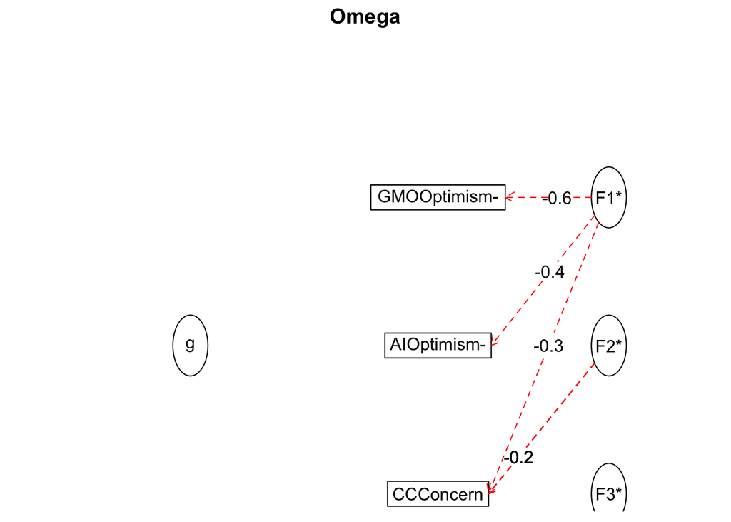

```
## Omega
## Call: omegah(m = m, nfactors = nfactors, fm = fm, key = key, flip = flip,
##     digits = digits, title = title, sl = sl, labels = labels,
##     plot = plot, n.obs = n.obs, rotate = rotate, Phi = Phi, option = option,
##     covar = covar)
## Alpha:                 0.37
## G.6:                   0.3
## Omega Hierarchical:    0
## Omega H asymptotic:    0
## Omega Total            0.43
##
## Schmid Leiman Factor loadings greater than  0.2
##                  g   F1*   F2*   F3*   h2   u2 p2
## GMOOptimism-       -0.61             0.38 0.62  0
## AIOptimism-        -0.44             0.23 0.77  0
## CCConcern          -0.25 -0.22       0.11 0.89  0
##
## With eigenvalues of:
##    g  F1*  F2*  F3*
## 0.00 0.63 0.09 0.00
##
## general/max  0   max/min =   Inf
## mean percent general =  0    with sd =  0 and cv of  NaN
## Explained Common Variance of the general factor =  0
##
## The degrees of freedom are -3  and the fit is  0
## The number of observations was  154195  with Chi Square =  0  with prob <  NA
## The root mean square of the residuals is  0
## The df corrected root mean square of the residuals is  NA
##
## Compare this with the adequacy of just a general factor and no group factors
## The degrees of freedom for just the general factor are 0  and the fit is  0.1
## The number of observations was  154195  with Chi Square =  15197.75  with prob <  NA
## The root mean square of the residuals is  0.18
## The df corrected root mean square of the residuals is  NA
##
## Measures of factor score adequacy
##                                                   g   F1*   F2* F3*
## Correlation of scores with factors             0.04  0.69  0.31   0
## Multiple R square of scores with factors       0.00  0.48  0.10   0
## Minimum correlation of factor score estimates -1.00 -0.04 -0.81  -1
##
##  Total, General and Subset omega for each subset
##                                                  g  F1* F2* F3*
## Omega total for total scores and subscales    0.43 0.43  NA  NA
## Omega general for total scores and subscales  0.00 0.00  NA  NA
## Omega group for total scores and subscales    0.43 0.43  NA  NA
```

```r
# Do big-picture and/or mundane worries form reliable scales? What about beliefs in government safety efficacy?
omega(m = mydata[c("GMOOptimism", "AIOptimism", "CCConcern")])  #Can't use survey weights, but overall the three big-picture items DO NOT seem to hang. alpha = 0.37, omega = 0.43
```

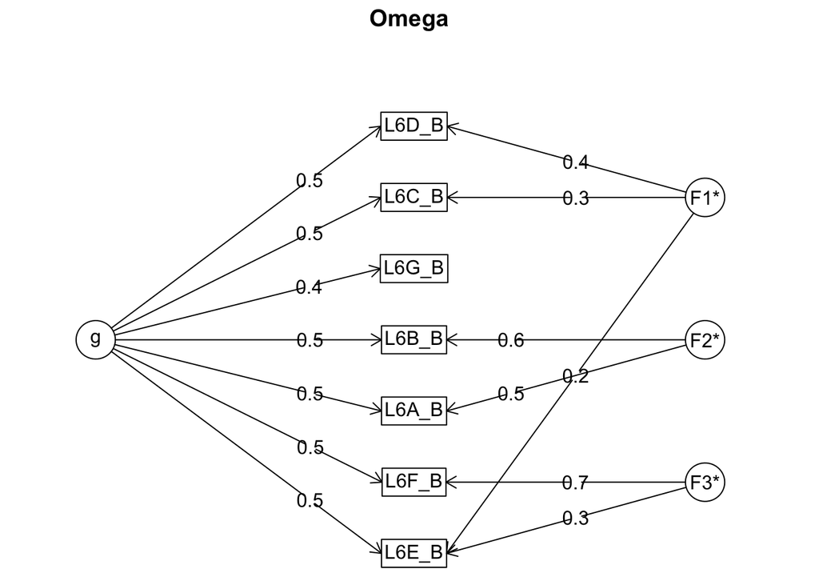

```
## Omega
## Call: omegah(m = m, nfactors = nfactors, fm = fm, key = key, flip = flip,
##     digits = digits, title = title, sl = sl, labels = labels,
##     plot = plot, n.obs = n.obs, rotate = rotate, Phi = Phi, option = option,
##     covar = covar)
## Alpha:                 0.76
## G.6:                   0.74
## Omega Hierarchical:    0.62
## Omega H asymptotic:    0.77
## Omega Total            0.81
##
## Schmid Leiman Factor loadings greater than  0.2
##          g   F1*   F2*   F3*   h2   u2   p2
## L6A_B 0.47        0.48       0.46 0.54 0.49
## L6B_B 0.50        0.56       0.56 0.44 0.44
## L6C_B 0.52  0.30             0.37 0.63 0.73
## L6D_B 0.55  0.39             0.45 0.55 0.66
## L6E_B 0.54  0.22        0.27 0.42 0.58 0.71
## L6F_B 0.49              0.66 0.67 0.33 0.35
## L6G_B 0.43                   0.25 0.75 0.76
##
## With eigenvalues of:
##    g  F1*  F2*  F3*
## 1.77 0.32 0.56 0.53
##
## general/max  3.14   max/min =   1.75
## mean percent general =  0.59    with sd =  0.16 and cv of  0.27
## Explained Common Variance of the general factor =  0.56
##
## The degrees of freedom are 3  and the fit is  0
## The number of observations was  154195  with Chi Square =  346.36  with prob <  9.2e-75
## The root mean square of the residuals is  0.01
## The df corrected root mean square of the residuals is  0.02
## RMSEA index =  0.027  and the 10 % confidence intervals are  0.025 0.03
## BIC =  310.52
##
## Compare this with the adequacy of just a general factor and no group factors
## The degrees of freedom for just the general factor are 14  and the fit is  0.22
## The number of observations was  154195  with Chi Square =  33698.68  with prob <  0
## The root mean square of the residuals is  0.09
## The df corrected root mean square of the residuals is  0.11
##
## RMSEA index =  0.125  and the 10 % confidence intervals are  0.124 0.126
## BIC =  33531.44
##
## Measures of factor score adequacy
##                                                  g   F1*   F2*  F3*
## Correlation of scores with factors            0.79  0.48  0.66 0.71
## Multiple R square of scores with factors      0.63  0.23  0.44 0.51
## Minimum correlation of factor score estimates 0.25 -0.53 -0.13 0.02
##
##  Total, General and Subset omega for each subset
##                                                  g  F1*  F2*  F3*
## Omega total for total scores and subscales    0.81 0.61 0.68 0.67
## Omega general for total scores and subscales  0.62 0.45 0.31 0.37
## Omega group for total scores and subscales    0.14 0.15 0.36 0.30
```

```r
omega(m = mydata[c(95:101)])  #Can't use survey weights, but overall the 7 mundane concern DO seem to form a scale. alpha = 0.76, omega = 0.81, all factors load at least 0.43 onto g. Let's sum and rename scale to MundaneWorryScore
```

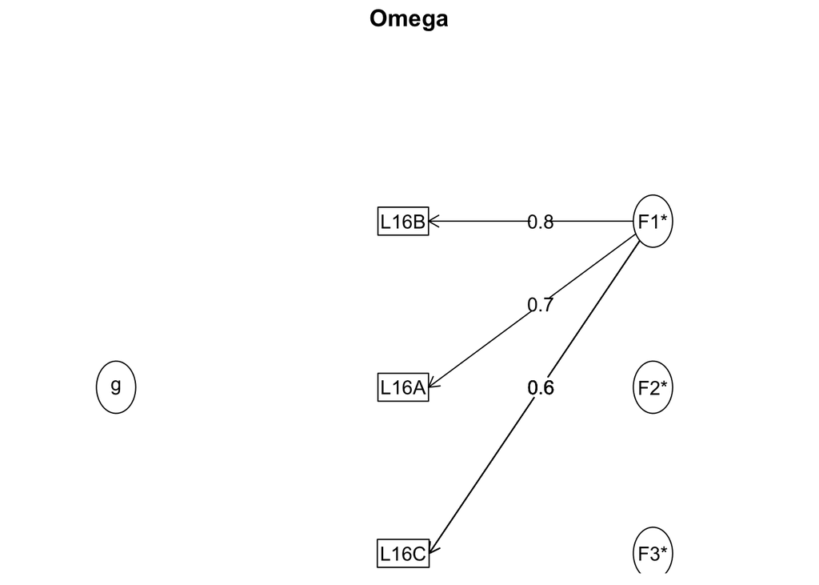

```
## Omega
## Call: omegah(m = m, nfactors = nfactors, fm = fm, key = key, flip = flip,
##     digits = digits, title = title, sl = sl, labels = labels,
##     plot = plot, n.obs = n.obs, rotate = rotate, Phi = Phi, option = option,
##     covar = covar)
## Alpha:                 0.77
## G.6:                   0.69
## Omega Hierarchical:    0.04
## Omega H asymptotic:    0.06
## Omega Total            0.78
##
## Schmid Leiman Factor loadings greater than  0.2
##          g  F1*   F2*   F3*   h2   u2   p2
## L16A       0.72             0.55 0.45 0.04
## L16B       0.80             0.68 0.32 0.06
## L16C       0.60             0.41 0.59 0.07
##
## With eigenvalues of:
##    g  F1*  F2*  F3*
## 0.09 1.52 0.02 0.00
##
## general/max  0.06   max/min =   Inf
## mean percent general =  0.06    with sd =  0.02 and cv of  0.27
## Explained Common Variance of the general factor =  0.06
##
## The degrees of freedom are -3  and the fit is  0
## The number of observations was  154195  with Chi Square =  0  with prob <  NA
## The root mean square of the residuals is  0
## The df corrected root mean square of the residuals is  NA
##
## Compare this with the adequacy of just a general factor and no group factors
## The degrees of freedom for just the general factor are 0  and the fit is  0.72
## The number of observations was  154195  with Chi Square =  110597.2  with prob <  NA
## The root mean square of the residuals is  0.5
## The df corrected root mean square of the residuals is  NA
##
## Measures of factor score adequacy
##                                                   g  F1*   F2* F3*
## Correlation of scores with factors             0.21 0.87  0.21   0
## Multiple R square of scores with factors       0.05 0.76  0.04   0
## Minimum correlation of factor score estimates -0.91 0.51 -0.91  -1
##
##  Total, General and Subset omega for each subset
##                                                  g  F1* F2* F3*
## Omega total for total scores and subscales    0.78 0.78  NA  NA
## Omega general for total scores and subscales  0.04 0.04  NA  NA
## Omega group for total scores and subscales    0.73 0.73  NA  NA
```

```r
mydata <- mydata %>%
  mutate(MundaneWorryScore = L6A_B + L6B_B + L6C_B + L6D_B + L6E_B + L6F_B + L6G_B)
#describe(mydata$MundaneWorryScore)

omega(m = mydata[c("L16A", "L16B", "L16C")]) #Beliefs in gov safety efficacy: alpha = 0.77, omega = 0.78 -- good enough for me
```

```r
mydata <- mydata %>%
  mutate(GovSafeEff = L16A + L16B + L16C)
#describe(mydata$GovSafeEff)

# Let's country-mean center our belief-in-government-safety-efficacy and mundane worries scales
mydata <- mydata %>%
  group_by(Country) %>%   # operate within countries
  mutate(GovSafeEff_cm = mean(GovSafeEff),   # create cluster means
         GovSafeEff_cmc = GovSafeEff - GovSafeEff_cm) %>%   # cluster-mean centered
    mutate(MundaneWorryScore_cm = mean(MundaneWorryScore),   # create cluster means
         MundaneWorryScore_cmc = MundaneWorryScore - MundaneWorryScore_cm) %>%   # cluster-mean centered
      mutate(AIOptimism_cm = mean(AIOptimism),   # create cluster means
         AIOptimism_cmc = AIOptimism - AIOptimism_cm) %>%   # cluster-mean centered
  ungroup()  # exit the "editing within groups" mode

# Do any of the big-picture concerns correlate with concern for nuclear power?
weightedCorr(mydata$NukeOptimism,mydata$GMOOptimism, weights = mydata$projection_weight) #R of 0.24 for nuclear X GMO
```

```
## [1] 0.2400537
```

```r
weightedCorr(mydata$NukeOptimism,mydata$AIOptimism, weights = mydata$projection_weight) #R of 0.27 for nuclear X AI
```

```
## [1] 0.268504
```

```r
weightedCorr(mydata$NukeOptimism,mydata$CCConcern, weights = mydata$projection_weight) #R of -0.11 for nuclear X Climate change. Interpretation -- the more afraid you are of climate change (i.e. high CCConern), the more you think that nuclear power is likely to HARM your country
```

```
## [1] -0.1076575
```

Takeaways: * The countries most in-favor of nuclear power all seem quite poor / developing. The countries most afraid of nuclear power are mostly European / wealthier (though more Eastern/Southern, aka the less wealthy parts of the continent). I know that in those parts of the world, citizens are less trusting of their governments, so now I’m doubly excited to test the trust-in-government-safety scale * Interesting that optimism for nuclear power is negatively correlated with concern for climate change. If you’re pro-nukes, you less likely to be concerned about climate change // if you’re concerned about climate change, you’re likely to be more pessimistic about nukes

## Modeling

Model equation (random intercepts only):

$$NukeOptimism_{ij} = \beta_{0j} + \beta_{1j} * AIOptimism_{ij} + \beta_{2j} *MundaneWorryScore_{ij} + e_{ij} \\
\beta_{0i} = \gamma_{00} + \gamma_{01}*AIOptimism_{cm} +\gamma_{02}*MundaneWorryScore_
{cm} + u_{0j} \\
\beta_{1j} = \gamma_{10} \\
\beta_{2j} = \gamma_{20}$$

```r
#Let's start with an empty model of nuclear optimism -- using controls only
m0 <- lmer(NukeOptimism ~ as.factor(INCOME_5) + Age + as.factor(Education) + as.factor(Gender) + (1 | Country), weights = projection_weight, data=mydata)
#summary(m0)

# Now let's add worry score predictor and AI optimism predictor
m1 <- lmer(NukeOptimism ~ MundaneWorryScore_cm + MundaneWorryScore_cmc + AIOptimism_cm + AIOptimism_cmc  + as.factor(INCOME_5) + Age + as.factor(Education) + as.factor(Gender) + (1 | Country), weights = projection_weight, data=mydata)
summary(m1)
```

```
## Linear mixed model fit by REML. t-tests use Satterthwaite's method [
## lmerModLmerTest]
## Formula: NukeOptimism ~ MundaneWorryScore_cm + MundaneWorryScore_cmc +
##     AIOptimism_cm + AIOptimism_cmc + as.factor(INCOME_5) + Age +
##     as.factor(Education) + as.factor(Gender) + (1 | Country)
##    Data: mydata
## Weights: projection_weight
##
## REML criterion at convergence: 567245.4
##
## Scaled residuals:
##     Min      1Q  Median      3Q     Max
## -9.4128 -0.3549 -0.0065  0.3713  7.6061
##
## Random effects:
##  Groups   Name        Variance  Std.Dev.
##  Country  (Intercept) 3.749e-02   0.1936
##  Residual             2.095e+04 144.7491
## Number of obs: 151663, groups:  Country, 141
##
## Fixed effects:
##                         Estimate Std. Error         df t value Pr(>|t|)
## (Intercept)           -3.120e-01  9.018e-02  1.494e+02  -3.459 0.000706 ***
## MundaneWorryScore_cm   8.557e-02  2.266e-02  1.453e+02   3.776 0.000231 ***
## MundaneWorryScore_cmc -2.166e-02  9.368e-04  1.515e+05 -23.119  < 2e-16 ***
## AIOptimism_cm          8.495e-01  7.901e-02  1.469e+02  10.752  < 2e-16 ***
## AIOptimism_cmc         2.369e-01  2.535e-03  1.515e+05  93.465  < 2e-16 ***
## as.factor(INCOME_5)2  -1.956e-02  6.318e-03  1.515e+05  -3.095 0.001965 **
## as.factor(INCOME_5)3  -8.372e-03  6.341e-03  1.515e+05  -1.320 0.186731
## as.factor(INCOME_5)4  -1.457e-02  6.406e-03  1.516e+05  -2.274 0.022985 *
## as.factor(INCOME_5)5  -1.161e-02  6.623e-03  1.516e+05  -1.753 0.079679 .
## Age                    3.412e-04  1.260e-04  1.513e+05   2.707 0.006780 **
## as.factor(Education)2 -4.089e-04  5.054e-03  1.502e+05  -0.081 0.935523
## as.factor(Education)3  3.631e-02  7.438e-03  1.505e+05   4.881 1.06e-06 ***
## as.factor(Gender)2    -3.685e-02  4.025e-03  1.515e+05  -9.157  < 2e-16 ***
## ---
## Signif. codes:  0 '***' 0.001 '**' 0.01 '*' 0.05 '.' 0.1 ' ' 1
```

```
##
## Correlation matrix not shown by default, as p = 13 > 12.
## Use print(x, correlation=TRUE)  or
##     vcov(x)        if you need it
```

```
## optimizer (nloptwrap) convergence code: 0 (OK)
## Model is nearly unidentifiable: very large eigenvalue
##  - Rescale variables?
```

```r
# The more worried you are, the less optimistic you'll be about nuclear power. Makes sense!

# Let's get a pseudo-R-squared for this model -- how is it zero?
MuMIn::r.squaredGLMM(m1)
```

```
##               R2m          R2c
## [1,] 3.784487e-06 5.573901e-06
```

```r
# Regardless, let's generate a table of coefficient outputs
msummary(m1)
```

|  | Model 1 |
| --- | --- |
| (Intercept) | −0.312 |
|  | (0.090) |
| MundaneWorryScore_cm | 0.086 |
|  | (0.023) |
| MundaneWorryScore_cmc | −0.022 |
|  | (0.001) |
| AIOptimism_cm | 0.850 |
|  | (0.079) |
| AIOptimism_cmc | 0.237 |
|  | (0.003) |
| as.factor(INCOME_5)2 | −0.020 |
|  | (0.006) |
| as.factor(INCOME_5)3 | −0.008 |
|  | (0.006) |
| as.factor(INCOME_5)4 | −0.015 |
|  | (0.006) |
| as.factor(INCOME_5)5 | −0.012 |
|  | (0.007) |
| Age | 0.000 |
|  | (0.000) |
| as.factor(Education)2 | 0.000 |
|  | (0.005) |
| as.factor(Education)3 | 0.036 |
|  | (0.007) |
| as.factor(Gender)2 | −0.037 |
|  | (0.004) |
| SD (Intercept) | 0.194 |
| SD (Observations) | 12.031 |
| Num.Obs. | 151663 |
| R2 Marg. | 0.000 |
| R2 Cond. | 0.000 |
| AIC | 567275.4 |
| BIC | 567424.3 |
| ICC | 0.0 |
| RMSE | 0.78 |